# CNN_XRAY_CF

## COVID-19 X-ray images classification

#### Author: Yilin Xu

#### Date: Mar.12.2021

#### Introduction:

- " The novel coronavirus 2019 (COVID-19), which first appeared in Wuhan, China in December 2019, spread rapidly around the world and became a global pandemic. This resulted in a devastating effect on both daily lives, public health, and the global economy. It is critical to detect the positive cases as early as possible to prevent the further spread of this epidemic and to quickly treat infected patients. The need for auxiliary diagnostic tools has increased as there are no accurate automated toolkits available. Recent findings obtained using radiology imaging techniques suggest that such images contain salient information about the COVID-19 virus. Application of advanced artificial intelligence (AI) techniques coupled with radiological imaging can be helpful for the accurate detection of this disease, and can also be assistive to overcome the problem of a lack of specialized physicians in remote villages."
- This notebook is a replication of the DarkCovidNet model<sup>1</sup> and transfer learning of GoogLeNet model to classify radiological images as indicative of either "COVID-19", "No Finding" and "Pneumonia" to assist in the diagnosis of COVID-19. This is an extension of the notebook published along with the paper in GitHub https://github.com/muhammedtalo/COVID-19/blob/master/DarkCovidNet%20%20for%20binary%20classes.ipynb. We use data available in Kaggle https://www.kaggle.com/tawsifurrahman/covid19-radiography-database
1. Ozturk et. al. 2020. Automated detection of COVID-19 cases using deep neural networks with X-ray. Comput Biol Med. 2020 Jun; 121: 103792. (doi: 10.1016/j.compbiomed.2020.103792).

#### Set up notebook

```python
%reload_ext autoreload
%autoreload 2
%matplotlib inline
import warnings
warnings.filterwarnings('ignore')
```

The Vision module in fastai package contains the classification methods we will use. Uncomment to install python package.

```python
# !pip install fastai==1.0.61 --user --no-use-pep517
# !pip install gitpython
# !pip install kaggle
from fastai.vision import *
import torchvision.models as TorchModels
import numpy as np
import shutil
from pathlib import Path
from sklearn.model_selection import StratifiedKFold
from sklearn.metrics import confusion_matrix
from sklearn.metrics import classification_report
from sklearn.metrics import roc_curve
from sklearn.metrics import auc
import os
```

### DarkCovidNet for image classification

#### Download X-RAY images from Kaggle API

To use the Kaggle API, sign up for a Kaggle account at https://www.kaggle.com. Then go to the 'Account' tab of your user profile (https://www.kaggle.com//account) and select 'Create API Token'. This will trigger the download of kaggle.json, a file containing your API credentials.

Set up Enviroment variables from the command line using information in kaggle.json:

- export KAGGLE_USERNAME="Your USER Name"
- export KAGGLE_KEY="Your PW"

Download Kaggle Dataset from the commnad line:

- kaggle datasets download -d tawsifurrahman/covid19-radiography-database

Unzip downloaded dataset:

- unzip covid19-radiography-database.zip

#### Clean up Dataset

Delete excel files that contains metadata and README file from command line:

- rm Normal.metadata.xlsx COVID.metadata.xlsx README.md.txt Lung_Opacity.metadata.xlsx Viral\ Pneumonia.metadata.xlsx

Delete Lung_Opacity folder from command line:

- rm -r Lung_Opacity

Change folder name from command line:

- mv Viral\ Pneumonia Viral_Pneumonia

Keep the same amount of images in all three categories:

- Comparing three folder, Viral_Pneumonia has the least amount of image files. Keep all the image files within this folder.
- Keep the same amount of files in the COVID and Normal folder

  ls Normal/|sort -n -k1.8|head -1345 > NORMAL_file.txt

  ls COVID/|sort -n -k1.7|head -1345 > COVID_file.txt

  cd Normal/

  ls|egrep -vf ../NORMAL_file.txt|xargs -n 1 echo rm > rmscript

  sh -x rmscript

  cd ../COVID

  ls|egrep -vf ../COVID_file.txt|xargs -n 1 echo rm > rmscript

  sh -x rmscript

  cd ..

  rm NORMAL_file.txt COVID_file.txt

#### Load Image data as ImageDataBunch object

Declare path of image files which are organized in different folders representing distinct categories.

```python
path = Path('COVID-19_Radiography_Dataset')
```

- All of the images are the 256 * 256 pixels and batch size is defined as 32
- The image data is normalized to have a mean of 0 and a standard deviation of 1
- We randomly seperate images to trainning and testing dataets in an 4:1 ratio with a random seed of 41

```python
np.random.seed(41)
bs = 32
data = ImageDataBunch.from_folder(path,train=".", valid_pct =0.2,
        ds_tfms = get_transforms(),size=(256,256),bs=bs,num_workers=0).normalize()
```

Show image group names,group numbers,size of trainning images and size of validation image

```python
data.classes, data.c, len(data.train_ds), len(data.valid_ds)
```

```
(['COVID', 'Normal', 'Viral_Pneumonia'], 3, 3228, 807)
```

#### Show a subset of normalized x-ray images (5 row * 5 column)

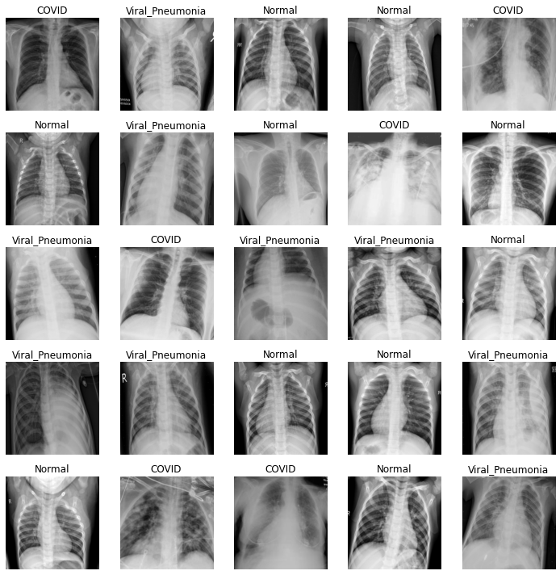

```python
data.show_batch(row=5,figsize=(10,10))
```

#### Construct DarkCovidNet CNN for three classes (modified Darknet model)

- Define one layer of the convolutional neural network using fastai and PyTorch
- Each layer has one convolution, one normalization, and one activation
- We use LeakyReLU with a negative slope of 0.1 as the activation function

ni: number of input (number of channels in the input image).

nf: number of filter.

size: kernel_size (size of the convolving kernel).

stride: skip number.

padding: amount of pixels adding to the input image.

```python
def conv_block(ni, nf, size=3, stride=1):
    """
    Define 2D convolution layer
    """
    for_pad = lambda s: s if s > 2 else 3
    return nn.Sequential(
        nn.Conv2d(ni, nf, kernel_size=size, stride=stride,
                  padding=(for_pad(size) - 1)//2, bias=False),
        nn.BatchNorm2d(nf),
        nn.LeakyReLU(negative_slope=0.1, inplace=True)
    )
```

Define triple convolution layers.

```python
def triple_conv(ni, nf):
    """
    Stack 2D convolution layers
    """
    return nn.Sequential(
        conv_block(ni, nf),
        conv_block(nf, ni, size=1),
        conv_block(ni, nf)
    )
```

Define maxpooling with size of 2 and stride of 2 to extract most activated presence of a feature

```python
 def maxpooling():
    """
    Define maxpooling method
    """
    return nn.MaxPool2d(2, stride=2)
```

- Construct DarkCovidNet architecture with 17 convolution layers
- The number of filters are gradually increased (e.g., 8,16,32)

```python
def darkcovidnet_model():
    """
    Construct cnn architecture for DarkCovidNet model
    """
    model = nn.Sequential(
        conv_block(3, 8),
        maxpooling(),
        conv_block(8, 16),
        maxpooling(),
        triple_conv(16, 32),
        maxpooling(),
        triple_conv(32, 64),
        maxpooling(),
        triple_conv(64, 128),
        maxpooling(),
        triple_conv(128, 256),
        conv_block(256, 128, size=1),
        conv_block(128, 256),
        conv_layer(256, 3),
        Flatten(),
        nn.Linear(507, 3)
    )
    return model
```

```python
model = darkcovidnet_model()
```

```python
learn = Learner(data, model, loss_func = nn.CrossEntropyLoss(), metrics=accuracy)
```

DarkCovidNet CNN summary

```python
print(learn.summary())
```

```
Sequential
======================================================================
Layer (type)         Output Shape         Param #    Trainable
======================================================================
Conv2d               [8, 256, 256]        216        True
______________________________________________________________________
BatchNorm2d          [8, 256, 256]        16         True
______________________________________________________________________
LeakyReLU            [8, 256, 256]        0          False
______________________________________________________________________
MaxPool2d            [8, 128, 128]        0          False
______________________________________________________________________
Conv2d               [16, 128, 128]       1,152      True
______________________________________________________________________
BatchNorm2d          [16, 128, 128]       32         True
______________________________________________________________________
LeakyReLU            [16, 128, 128]       0          False
______________________________________________________________________
MaxPool2d            [16, 64, 64]         0          False
______________________________________________________________________
Conv2d               [32, 64, 64]         4,608      True
______________________________________________________________________
BatchNorm2d          [32, 64, 64]         64         True
______________________________________________________________________
LeakyReLU            [32, 64, 64]         0          False
______________________________________________________________________
Conv2d               [16, 66, 66]         512        True
______________________________________________________________________
BatchNorm2d          [16, 66, 66]         32         True
______________________________________________________________________
LeakyReLU            [16, 66, 66]         0          False
______________________________________________________________________
Conv2d               [32, 66, 66]         4,608      True
______________________________________________________________________
BatchNorm2d          [32, 66, 66]         64         True
______________________________________________________________________
LeakyReLU            [32, 66, 66]         0          False
______________________________________________________________________
MaxPool2d            [32, 33, 33]         0          False
______________________________________________________________________
```

[output cut: 74 more lines]

```
BatchNorm2d          [3, 13, 13]          6          True
______________________________________________________________________
Flatten              [507]                0          False
______________________________________________________________________
Linear               [3]                  1,524      True
______________________________________________________________________

Total params: 1,167,586
Total trainable params: 1,167,586
Total non-trainable params: 0
Optimized with 'torch.optim.adam.Adam', betas=(0.9, 0.99)
Using true weight decay as discussed in https://www.fast.ai/2018/07/02/adam-weight-decay/
Loss function : CrossEntropyLoss
======================================================================
Callbacks functions applied
```

Plot the learning rate vs loss to identify the maximum learning rate.

0.00% [0/1 00:00<00:00]

| epoch | train_loss | valid_loss | accuracy | time |
| --- | --- | --- | --- | --- |

90.00% [90/100 01:17<00:08 2.7923]

```
LR Finder is complete, type {learner_name}.recorder.plot() to see the graph.
```

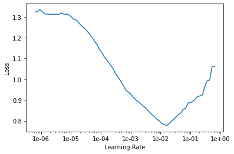

```python
learn.lr_find()
learn.recorder.plot()
del model
```

#### Apply sklearn stratified 5 fold cross validation

- All of the images are the 256 * 256 pixels and batch size is defined as 32
- The image data is normalized to have a mean of 0 and a standard deviation of 1
- We will perfomr 5 fold cross validation with train and validation ratio of 4:1
- Use fastai.vision.learner to train a randomly initialized model. Our loss function, cross-entropy loss measures the performance of a classification model as a probability value between 0 and 1. Cross-entropy loss increases as the predicted probability diverges from the actual label.

```python
tfms = get_transforms()
data = (ImageList.from_folder(path).split_by_rand_pct(valid_pct=0.2).
        label_from_folder().transform(tfms,size=256).
        databunch(bs=bs,num_workers=0).normalize())
```

```python
df = data.to_df()
df.head()
```

|  | x | y |
| --- | --- | --- |
| 0 | COVID/COVID-292.png | COVID |
| 1 | COVID/COVID-973.png | COVID |
| 2 | COVID/COVID-1226.png | COVID |
| 3 | COVID/COVID-160.png | COVID |
| 4 | COVID/COVID-410.png | COVID |

```python
skf = StratifiedKFold(n_splits=5,shuffle=True,random_state=1)
```

```python
# Extract loss and accuracy values
def extract_values(data,epoch,learner,bs):
    """
    Extract loss value for train set, validation set and accuracy for validation set at end of training for each epoch
    """
    segment = math.floor(len(data.train_ds)/bs)
    epoch_list = list(range(1,epoch+1))
    index = [x*segment-1 for x in epoch_list]
    train_loss = [float(learner.recorder.losses[i]) for i in index]
    val_loss = learner.recorder.val_losses
    accuracy = [float(x[0]) for x in learner.recorder.metrics]
    return train_loss, val_loss,accuracy
```

```python
# Plot loss and accuracy values
def plot_matrix(epoch,train_loss,val_loss,accuracy):
    """
    Plot curves for trainning loss, validation loss and accuracy per epoch
    """
    fig = plt.figure()
    ax1 = fig.add_subplot(111)
    ax1.set_ylim([0, 1])
    epoch_list = list(range(1,epoch+1))
    ax1.plot(epoch_list,train_loss,zorder=1)
    ax1.scatter(epoch_list, train_loss, s=10, c='b', marker="s", label='train_loss')
    ax1.plot(epoch_list,val_loss,zorder=1)
    ax1.scatter(epoch_list,val_loss, s=10, c='r', marker="o", label='val_loss')
    ax1.plot(epoch_list,accuracy,zorder=1)
    ax1.scatter(epoch_list,accuracy, s=10, c='g', marker="o", label='accuracy')
    plt.legend(loc='lower left');
    plt.show()
```

```
Data classes ['COVID', 'Normal', 'Viral_Pneumonia']
Number of train images: 2582
Number of validation images: 646
Train with DarkCovidNet CNN
```

| epoch | train_loss | valid_loss | accuracy | time |
| --- | --- | --- | --- | --- |
| 0 | 0.441121 | 0.307047 | 0.890093 | 01:14 |
| 1 | 0.338170 | 0.418514 | 0.866873 | 01:15 |
| 2 | 0.303682 | 0.249466 | 0.914861 | 01:16 |
| 3 | 0.317849 | 0.411785 | 0.879257 | 01:16 |
| 4 | 0.322523 | 0.367404 | 0.866873 | 01:16 |
| 5 | 0.312729 | 0.409737 | 0.883901 | 01:16 |
| 6 | 0.308189 | 0.219385 | 0.924149 | 01:14 |
| 7 | 0.287203 | 0.444894 | 0.882353 | 01:15 |
| 8 | 0.288520 | 0.255312 | 0.916409 | 01:16 |
| 9 | 0.293425 | 0.523388 | 0.795666 | 01:15 |
| 10 | 0.276972 | 0.234679 | 0.919505 | 01:15 |
| 11 | 0.299869 | 0.246122 | 0.917957 | 01:15 |
| 12 | 0.247003 | 0.189437 | 0.941176 | 01:13 |
| 13 | 0.241332 | 0.239806 | 0.913313 | 01:15 |
| 14 | 0.237079 | 0.312291 | 0.905573 | 01:15 |
| 15 | 0.245134 | 0.200944 | 0.927245 | 01:15 |
| 16 | 0.235535 | 0.155856 | 0.939628 | 01:15 |
| 17 | 0.212813 | 0.195590 | 0.936532 | 01:16 |
| 18 | 0.206211 | 0.163867 | 0.942724 | 01:15 |
| 19 | 0.201841 | 0.153287 | 0.950464 | 01:15 |
| 20 | 0.192294 | 0.166187 | 0.933437 | 01:16 |
| 21 | 0.192428 | 0.169578 | 0.939628 | 01:16 |
| 22 | 0.179407 | 0.197020 | 0.936532 | 01:15 |
| 23 | 0.176410 | 0.174147 | 0.934985 | 01:13 |
| 24 | 0.155530 | 0.108708 | 0.962848 | 01:16 |
| 25 | 0.139738 | 0.161122 | 0.947368 | 01:13 |
| 26 | 0.126609 | 0.144945 | 0.948916 | 01:15 |
| 27 | 0.128557 | 0.147564 | 0.945820 | 01:16 |
| 28 | 0.125116 | 0.140124 | 0.953560 | 01:16 |
| 29 | 0.114293 | 0.149392 | 0.944272 | 01:16 |
| 30 | 0.111693 | 0.152918 | 0.942724 | 01:16 |
| 31 | 0.108747 | 0.137615 | 0.952012 | 01:15 |
| 32 | 0.108244 | 0.134473 | 0.948916 | 01:16 |
| 33 | 0.111880 | 0.126150 | 0.950464 | 01:16 |
| 34 | 0.105968 | 0.131549 | 0.948916 | 01:16 |

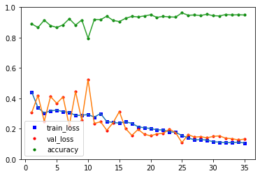

```
Data classes ['COVID', 'Normal', 'Viral_Pneumonia']
Number of train images: 2582
Number of validation images: 646
Train with DarkCovidNet CNN
```

| epoch | train_loss | valid_loss | accuracy | time |
| --- | --- | --- | --- | --- |
| 0 | 0.427694 | 0.279958 | 0.908669 | 01:14 |
| 1 | 0.309187 | 0.234167 | 0.924149 | 01:16 |
| 2 | 0.293609 | 0.346286 | 0.866873 | 01:16 |
| 3 | 0.286625 | 0.277109 | 0.913313 | 01:17 |
| 4 | 0.304235 | 0.362059 | 0.868421 | 01:17 |
| 5 | 0.288488 | 0.329383 | 0.877709 | 01:15 |
| 6 | 0.296395 | 0.301690 | 0.896285 | 01:16 |
| 7 | 0.311394 | 0.359980 | 0.869969 | 01:16 |
| 8 | 0.290793 | 0.360851 | 0.890093 | 01:16 |
| 9 | 0.293046 | 0.320273 | 0.908669 | 01:15 |
| 10 | 0.269459 | 0.296408 | 0.893189 | 01:17 |
| 11 | 0.255452 | 0.254570 | 0.917957 | 01:15 |
| 12 | 0.248948 | 0.260873 | 0.907121 | 01:15 |
| 13 | 0.244352 | 0.254453 | 0.911765 | 01:17 |
| 14 | 0.236315 | 0.281520 | 0.914861 | 01:17 |
| 15 | 0.225243 | 0.293305 | 0.908669 | 01:14 |
| 16 | 0.214434 | 0.427300 | 0.888545 | 01:17 |
| 17 | 0.211616 | 0.251940 | 0.911765 | 01:16 |
| 18 | 0.189840 | 0.236912 | 0.928793 | 01:16 |
| 19 | 0.178367 | 0.262123 | 0.908669 | 01:14 |
| 20 | 0.173365 | 0.179314 | 0.942724 | 01:16 |
| 21 | 0.176934 | 0.184303 | 0.938080 | 01:16 |
| 22 | 0.165894 | 0.199973 | 0.936532 | 01:17 |
| 23 | 0.163187 | 0.192792 | 0.933437 | 01:17 |
| 24 | 0.157306 | 0.205550 | 0.922601 | 01:16 |
| 25 | 0.156361 | 0.186119 | 0.944272 | 01:15 |
| 26 | 0.131649 | 0.197238 | 0.933437 | 01:17 |
| 27 | 0.140728 | 0.180681 | 0.936532 | 01:16 |
| 28 | 0.131973 | 0.174431 | 0.939628 | 01:16 |
| 29 | 0.120536 | 0.153730 | 0.955108 | 01:14 |
| 30 | 0.107077 | 0.173050 | 0.948916 | 01:16 |
| 31 | 0.109106 | 0.185182 | 0.941176 | 01:17 |
| 32 | 0.097201 | 0.162892 | 0.955108 | 01:16 |
| 33 | 0.103402 | 0.172321 | 0.947368 | 01:16 |
| 34 | 0.093982 | 0.166738 | 0.953560 | 01:17 |

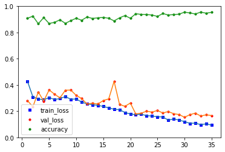

```
Data classes ['COVID', 'Normal', 'Viral_Pneumonia']
Number of train images: 2582
Number of validation images: 646
Train with DarkCovidNet CNN
```

| epoch | train_loss | valid_loss | accuracy | time |
| --- | --- | --- | --- | --- |
| 0 | 0.442435 | 0.228361 | 0.922601 | 01:16 |
| 1 | 0.349141 | 0.218714 | 0.927245 | 01:16 |
| 2 | 0.322447 | 0.237758 | 0.916409 | 01:14 |
| 3 | 0.303293 | 0.218970 | 0.936532 | 01:17 |
| 4 | 0.300713 | 0.368322 | 0.857585 | 01:17 |
| 5 | 0.303688 | 0.183710 | 0.948916 | 01:15 |
| 6 | 0.342197 | 0.347176 | 0.879257 | 01:16 |
| 7 | 0.326348 | 0.595128 | 0.756966 | 01:16 |
| 8 | 0.319700 | 0.400803 | 0.882353 | 01:16 |
| 9 | 0.274528 | 0.206474 | 0.938080 | 01:15 |
| 10 | 0.286120 | 0.284158 | 0.905573 | 01:15 |
| 11 | 0.246953 | 0.171637 | 0.956656 | 01:17 |
| 12 | 0.274969 | 0.465469 | 0.832817 | 01:15 |
| 13 | 0.257235 | 0.168472 | 0.933437 | 01:17 |
| 14 | 0.247023 | 0.366470 | 0.880805 | 01:17 |
| 15 | 0.243248 | 0.189001 | 0.956656 | 01:15 |
| 16 | 0.231513 | 0.186388 | 0.931889 | 01:18 |
| 17 | 0.225962 | 0.169407 | 0.955108 | 01:16 |
| 18 | 0.213065 | 0.151984 | 0.956656 | 01:16 |
| 19 | 0.198055 | 0.246870 | 0.930341 | 01:17 |
| 20 | 0.208660 | 0.286931 | 0.908669 | 01:17 |
| 21 | 0.194403 | 0.134675 | 0.964396 | 01:18 |
| 22 | 0.178594 | 0.132773 | 0.953560 | 01:15 |
| 23 | 0.160163 | 0.141081 | 0.956656 | 01:17 |
| 24 | 0.171147 | 0.121206 | 0.962848 | 01:17 |
| 25 | 0.150405 | 0.136430 | 0.961300 | 01:18 |
| 26 | 0.151785 | 0.144408 | 0.952012 | 01:16 |
| 27 | 0.138320 | 0.138421 | 0.959752 | 01:18 |
| 28 | 0.128987 | 0.134195 | 0.956656 | 01:15 |
| 29 | 0.134636 | 0.124053 | 0.964396 | 01:16 |
| 30 | 0.127968 | 0.126874 | 0.961300 | 01:16 |
| 31 | 0.123146 | 0.131010 | 0.956656 | 01:17 |
| 32 | 0.117373 | 0.128101 | 0.959752 | 01:15 |
| 33 | 0.124874 | 0.127480 | 0.959752 | 01:17 |
| 34 | 0.120296 | 0.130095 | 0.956656 | 01:17 |

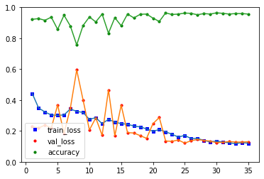

```
Data classes ['COVID', 'Normal', 'Viral_Pneumonia']
Number of train images: 2583
Number of validation images: 645
Train with DarkCovidNet CNN
```

| epoch | train_loss | valid_loss | accuracy | time |
| --- | --- | --- | --- | --- |
| 0 | 0.403912 | 0.303125 | 0.894574 | 01:15 |
| 1 | 0.322225 | 0.582632 | 0.793798 | 01:17 |
| 2 | 0.288751 | 0.295274 | 0.905426 | 01:17 |
| 3 | 0.283996 | 0.490962 | 0.810853 | 01:16 |
| 4 | 0.288496 | 0.465569 | 0.806202 | 01:17 |
| 5 | 0.298900 | 0.597757 | 0.753488 | 01:16 |
| 6 | 0.285054 | 1.712759 | 0.637209 | 01:14 |
| 7 | 0.298910 | 0.881428 | 0.756589 | 01:17 |
| 8 | 0.274528 | 0.224458 | 0.930233 | 01:16 |
| 9 | 0.238225 | 0.300646 | 0.903876 | 01:17 |
| 10 | 0.278465 | 0.427054 | 0.821705 | 01:14 |
| 11 | 0.247929 | 0.213735 | 0.925581 | 01:16 |
| 12 | 0.246127 | 0.258280 | 0.917829 | 01:16 |
| 13 | 0.237521 | 0.242424 | 0.919380 | 01:15 |
| 14 | 0.244814 | 0.226590 | 0.927132 | 01:17 |
| 15 | 0.226633 | 0.190341 | 0.950388 | 01:17 |
| 16 | 0.228008 | 0.212253 | 0.936434 | 01:17 |
| 17 | 0.211215 | 0.171420 | 0.948837 | 01:15 |
| 18 | 0.213551 | 0.170468 | 0.945736 | 01:17 |
| 19 | 0.190160 | 0.223352 | 0.922481 | 01:14 |
| 20 | 0.176311 | 0.172585 | 0.950388 | 01:16 |
| 21 | 0.164530 | 0.182140 | 0.948837 | 01:16 |
| 22 | 0.173520 | 0.164031 | 0.945736 | 01:14 |
| 23 | 0.168764 | 0.204508 | 0.931783 | 01:17 |
| 24 | 0.145748 | 0.164817 | 0.948837 | 01:15 |
| 25 | 0.147302 | 0.146811 | 0.956589 | 01:14 |
| 26 | 0.133978 | 0.158184 | 0.956589 | 01:17 |
| 27 | 0.130479 | 0.140546 | 0.959690 | 01:16 |
| 28 | 0.129938 | 0.142407 | 0.958140 | 01:13 |
| 29 | 0.117444 | 0.141415 | 0.955039 | 01:15 |
| 30 | 0.113339 | 0.146627 | 0.955039 | 01:16 |
| 31 | 0.108081 | 0.145653 | 0.958140 | 01:16 |
| 32 | 0.099071 | 0.146101 | 0.959690 | 01:16 |
| 33 | 0.102032 | 0.148499 | 0.958140 | 01:14 |
| 34 | 0.092741 | 0.142851 | 0.959690 | 01:16 |

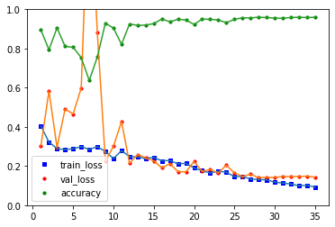

```
Data classes ['COVID', 'Normal', 'Viral_Pneumonia']
Number of train images: 2583
Number of validation images: 645
Train with DarkCovidNet CNN
```

| epoch | train_loss | valid_loss | accuracy | time |
| --- | --- | --- | --- | --- |
| 0 | 0.422727 | 0.268531 | 0.924031 | 01:16 |
| 1 | 0.325998 | 0.274769 | 0.906977 | 01:16 |
| 2 | 0.278108 | 0.257880 | 0.914729 | 01:16 |
| 3 | 0.289931 | 0.882540 | 0.691473 | 01:17 |
| 4 | 0.289479 | 0.433271 | 0.831008 | 01:17 |
| 5 | 0.284375 | 0.296845 | 0.885271 | 01:16 |
| 6 | 0.297004 | 0.303621 | 0.889922 | 01:16 |
| 7 | 0.306012 | 0.212236 | 0.930233 | 01:14 |
| 8 | 0.286759 | 0.472528 | 0.854264 | 01:16 |
| 9 | 0.294220 | 1.318604 | 0.649612 | 01:14 |
| 10 | 0.285846 | 0.338818 | 0.894574 | 01:16 |
| 11 | 0.273176 | 0.327640 | 0.883721 | 01:16 |
| 12 | 0.259439 | 0.305050 | 0.908527 | 01:16 |
| 13 | 0.241782 | 0.281097 | 0.897674 | 01:14 |
| 14 | 0.236940 | 0.209991 | 0.934884 | 01:16 |
| 15 | 0.227918 | 0.407755 | 0.880620 | 01:17 |
| 16 | 0.228091 | 0.181502 | 0.941085 | 01:17 |
| 17 | 0.203382 | 0.198345 | 0.939535 | 01:17 |
| 18 | 0.204847 | 0.260027 | 0.910078 | 01:16 |
| 19 | 0.195983 | 0.186124 | 0.936434 | 01:16 |
| 20 | 0.207561 | 0.155952 | 0.955039 | 01:16 |
| 21 | 0.185508 | 0.191300 | 0.936434 | 01:14 |
| 22 | 0.165064 | 0.198148 | 0.931783 | 01:16 |
| 23 | 0.168856 | 0.138625 | 0.947287 | 01:16 |
| 24 | 0.155701 | 0.178035 | 0.942636 | 01:16 |
| 25 | 0.141523 | 0.217549 | 0.924031 | 01:16 |
| 26 | 0.143099 | 0.139650 | 0.951938 | 01:15 |
| 27 | 0.123396 | 0.140593 | 0.958140 | 01:15 |
| 28 | 0.131912 | 0.136228 | 0.959690 | 01:13 |
| 29 | 0.126742 | 0.139127 | 0.950388 | 01:16 |
| 30 | 0.109577 | 0.150347 | 0.955039 | 01:16 |
| 31 | 0.105873 | 0.131683 | 0.948837 | 01:15 |
| 32 | 0.102929 | 0.136187 | 0.950388 | 01:16 |
| 33 | 0.105609 | 0.134000 | 0.950388 | 01:15 |
| 34 | 0.095169 | 0.124973 | 0.950388 | 01:14 |

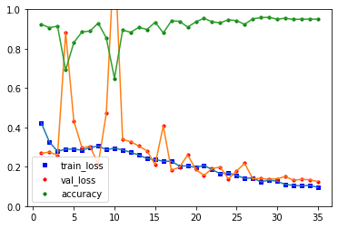

```
[0.9489164352416992, 0.9535603523254395, 0.9566563367843628, 0.9596899151802063, 0.9503875970840454]
```

```python
n_cv_round = 0
acc_val = []
epoch = 35
# Loop through each cv fold
for train_index,val_index in skf.split(df.index,df['y']):
    n_cv_round += 1
    # Load data
    data_fold = (ImageList.from_df(df,path).
                split_by_idxs(train_index,val_index).
                label_from_df().transform(tfms,size=256).
                databunch(num_workers=0,bs=bs)).normalize()
    print("This is the %d round of cross validation" %(n_cv_round))
    print("Data classes %s" %(data_fold.classes))
    print("Number of train images: %d" %(len(data_fold.train_ds)))
    print("Number of validation images: %d" %(len(data_fold.valid_ds)))
    print("Train with DarkCovidNet CNN")
    # Train model
    model = darkcovidnet_model()
    learn_fold = Learner(data_fold, model, loss_func = nn.CrossEntropyLoss(), metrics=accuracy)
    learn_fold.unfreeze()
    learn_fold.fit_one_cycle(epoch, max_lr=3e-3)
    train_loss, val_loss,accu = extract_values(data_fold,epoch,learn_fold,bs)
    plot_matrix(epoch,train_loss,val_loss,accu)
    acc_val.append(accu[-1])
    # Clean enviroment
    del learn_fold
    del model
print(acc_val)
```

#### Train DarkCovidNet CNN with overall dataset

```python
model = darkcovidnet_model()
learn = Learner(data, model, loss_func = nn.CrossEntropyLoss(), metrics=accuracy)
```

```python
epoch = 35
learn.unfreeze()
learn.fit_one_cycle(epoch, max_lr=3e-3)
```

| epoch | train_loss | valid_loss | accuracy | time |
| --- | --- | --- | --- | --- |
| 0 | 0.358919 | 0.228603 | 0.923172 | 01:35 |
| 1 | 0.297121 | 0.229963 | 0.924411 | 01:33 |
| 2 | 0.279122 | 0.230811 | 0.923172 | 01:31 |
| 3 | 0.270711 | 0.269675 | 0.908302 | 01:32 |
| 4 | 0.301581 | 0.529359 | 0.786865 | 01:32 |
| 5 | 0.315771 | 0.324720 | 0.920694 | 01:33 |
| 6 | 0.291465 | 1.241307 | 0.610905 | 01:32 |
| 7 | 0.303902 | 0.469503 | 0.850062 | 01:28 |
| 8 | 0.294705 | 0.616466 | 0.775712 | 01:30 |
| 9 | 0.283678 | 0.277688 | 0.900867 | 01:31 |
| 10 | 0.268225 | 0.202674 | 0.931846 | 01:29 |
| 11 | 0.248853 | 0.200431 | 0.936803 | 01:31 |
| 12 | 0.251852 | 0.173669 | 0.942999 | 01:34 |
| 13 | 0.249968 | 0.164119 | 0.941760 | 01:32 |
| 14 | 0.243807 | 0.381228 | 0.874845 | 01:31 |
| 15 | 0.202350 | 0.184439 | 0.936803 | 01:31 |
| 16 | 0.217320 | 0.500404 | 0.830235 | 01:32 |
| 17 | 0.204079 | 0.194628 | 0.925651 | 01:30 |
| 18 | 0.203677 | 0.207022 | 0.919455 | 01:30 |
| 19 | 0.197067 | 0.146694 | 0.952912 | 01:31 |
| 20 | 0.191175 | 0.145065 | 0.952912 | 01:32 |
| 21 | 0.186410 | 0.144621 | 0.951673 | 01:32 |
| 22 | 0.178244 | 0.308283 | 0.885998 | 01:31 |
| 23 | 0.150239 | 0.124978 | 0.951673 | 01:29 |
| 24 | 0.150263 | 0.120665 | 0.955390 | 01:32 |
| 25 | 0.144651 | 0.116471 | 0.956630 | 01:32 |
| 26 | 0.124824 | 0.177058 | 0.936803 | 01:30 |
| 27 | 0.126243 | 0.113584 | 0.959108 | 01:31 |
| 28 | 0.116136 | 0.106893 | 0.961586 | 01:30 |
| 29 | 0.112689 | 0.102066 | 0.959108 | 01:30 |
| 30 | 0.115407 | 0.109936 | 0.957869 | 01:31 |
| 31 | 0.104846 | 0.111252 | 0.957869 | 01:30 |
| 32 | 0.105893 | 0.106774 | 0.957869 | 01:30 |
| 33 | 0.094520 | 0.108107 | 0.959108 | 01:30 |
| 34 | 0.094198 | 0.110000 | 0.956630 | 01:30 |

#### Plot the Epoch and loss for both training data and validation data

The loss values decrease as the Epoch increases for both the training dataset and the validation dataset. When epoch exceeds 25, the loss values and accuracy values are stable. 35 Epoch is a good amount of times fitting the data to the model.

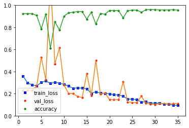

```python
train_loss, val_loss,accu = extract_values(data,epoch,learn,bs)
plot_matrix(epoch,train_loss,val_loss,accu)
```

#### Evaluate sensitivity, specificity, accuracy, precision, F1 score and plot confusion matrix, receiver operating characteristic

- Accrucy ACC = (TP + TN) / (P + N) * 100
- Precision PRE = TP / (TP + FP) * 100
- Recall RC = TP/P *100 = TP/(TP + FN)* 100
- F1 = 2TP / (2TP + FP+ FN)

```python
# Extract probability and labels for validation datset
probs,targets = learn.get_preds(ds_type=DatasetType.Valid)
# Prediction
probs = np.argmax(probs, axis=1)
```

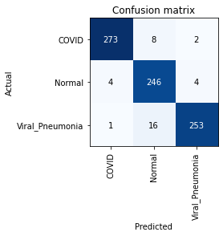

```python
# Plot confusion matrix
interp = ClassificationInterpretation.from_learner(learn)
cm_fig = interp.plot_confusion_matrix(return_fig=True)
ax = cm_fig.gca()
ax.set_ylim(interp.data.c - .5, - .5);
```

```python
# Plot classification report
target_names = ['Covid', 'Normal','Viral_Pneumonia']
print("Classification Report:")
print(classification_report(targets, probs, target_names=target_names))
```

```
Classification Report:
                 precision    recall  f1-score   support

          Covid       0.98      0.96      0.97       283
         Normal       0.91      0.97      0.94       254
Viral_Pneumonia       0.98      0.94      0.96       270

       accuracy                           0.96       807
      macro avg       0.96      0.96      0.96       807
   weighted avg       0.96      0.96      0.96       807
```

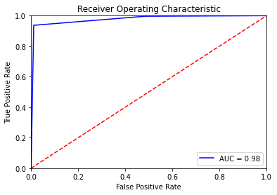

```python
# Receiver operating characteristic ROC is a probability curve created by plotting the TP rate against the FP rate at various threshold settings
fpr, tpr, _ = roc_curve(targets, probs, pos_label=2)
roc_auc = auc(fpr, tpr)

plt.title('Receiver Operating Characteristic')
plt.plot(fpr, tpr, 'b', label = 'AUC = %0.2f' % roc_auc)
plt.legend(loc = 'lower right')
plt.plot([0, 1], [0, 1],'r--')
plt.xlim([0, 1])
plt.ylim([0, 1])
plt.ylabel('True Positive Rate')
plt.xlabel('False Positive Rate')
plt.show()
```

### GoogleNet for image classification

Choose transfer learning model GoogleNet and Load DataBunch

```python
def googlenet_model():
    """
    Construct GoogleNet transfer learnning model
    """
    # Freeze GoogleNet weights
    googlenetModel = TorchModels.googlenet(pretrained=True)
    for param in googlenetModel.parameters():
        param.requires_grad = False
    # Adjust last layer to my dataset classes
    num_ftrs = googlenetModel.fc.in_features
    googlenetModel.fc = nn.Linear(num_ftrs, len(data.classes))
    return googlenetModel
```

```python
sz = 224 # image size for GoogleNet
googlenetModel = googlenet_model()
data = ImageDataBunch.from_folder(path,train=".", valid_pct =0.2,
        ds_tfms = get_transforms(googlenetModel,sz),bs=bs,num_workers=0)
```

#### Show a subset of transformed x-ray images (5 row * 5 column)

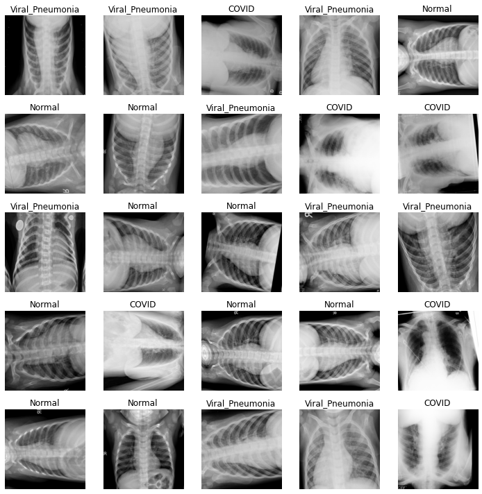

```python
data.show_batch(row=5,figsize=(10,10))
```

GoogleNet architecture

```python
opt_func = partial(optim.SGD,lr=0.003, momentum=0.9)
learn = Learner(data, googlenetModel,metrics=accuracy,opt_func=opt_func)
learn.summary()
```

```
GoogLeNet
======================================================================
Layer (type)         Output Shape         Param #    Trainable
======================================================================
Conv2d               [64, 150, 150]       9,408      False
______________________________________________________________________
BatchNorm2d          [64, 150, 150]       128        False
______________________________________________________________________
MaxPool2d            [64, 75, 75]         0          False
______________________________________________________________________
Conv2d               [64, 75, 75]         4,096      False
______________________________________________________________________
BatchNorm2d          [64, 75, 75]         128        False
______________________________________________________________________
Conv2d               [192, 75, 75]        110,592    False
______________________________________________________________________
BatchNorm2d          [192, 75, 75]        384        False
______________________________________________________________________
MaxPool2d            [192, 37, 37]        0          False
______________________________________________________________________
Conv2d               [64, 37, 37]         12,288     False
______________________________________________________________________
BatchNorm2d          [64, 37, 37]         128        False
______________________________________________________________________
Conv2d               [96, 37, 37]         18,432     False
______________________________________________________________________
BatchNorm2d          [96, 37, 37]         192        False
______________________________________________________________________
Conv2d               [128, 37, 37]        110,592    False
______________________________________________________________________
BatchNorm2d          [128, 37, 37]        256        False
______________________________________________________________________
Conv2d               [16, 37, 37]         3,072      False
______________________________________________________________________
BatchNorm2d          [16, 37, 37]         32         False
______________________________________________________________________
Conv2d               [32, 37, 37]         4,608      False
______________________________________________________________________
BatchNorm2d          [32, 37, 37]         64         False
______________________________________________________________________
```

[output cut: 219 more lines]

```
______________________________________________________________________
Dropout              [1024]               0          False
______________________________________________________________________
Linear               [3]                  3,075      True
______________________________________________________________________

Total params: 5,602,979
Total trainable params: 3,075
Total non-trainable params: 5,599,904
Optimized with 'torch.optim.sgd.SGD', lr=0.003, momentum=0.9
Using true weight decay as discussed in https://www.fast.ai/2018/07/02/adam-weight-decay/
 Specifying lr in the optimizer has no effect, pass it to fit or the defaults.lr will apply
Loss function : FlattenedLoss
======================================================================
Callbacks functions applied
```

#### Train modified GoogleNet

```python
epoch = 25
googlenetModel = googlenet_model()
learn = Learner(data, googlenetModel,metrics=accuracy,opt_func=opt_func)
learn.fit_one_cycle(epoch,max_lr = 0.003)
```

| epoch | train_loss | valid_loss | accuracy | time |
| --- | --- | --- | --- | --- |
| 0 | 0.983224 | 0.893451 | 0.609665 | 04:04 |
| 1 | 0.763791 | 0.605686 | 0.907063 | 04:00 |
| 2 | 0.571662 | 0.442440 | 0.910781 | 03:59 |
| 3 | 0.463039 | 0.379779 | 0.893432 | 04:02 |
| 4 | 0.408919 | 0.331211 | 0.894672 | 03:57 |
| 5 | 0.367516 | 0.283916 | 0.920694 | 03:59 |
| 6 | 0.352352 | 0.274099 | 0.918216 | 03:57 |
| 7 | 0.336198 | 0.294421 | 0.905824 | 03:57 |
| 8 | 0.318278 | 0.257982 | 0.915737 | 04:00 |
| 9 | 0.307957 | 0.239621 | 0.918216 | 03:57 |
| 10 | 0.316297 | 0.242735 | 0.912020 | 03:57 |
| 11 | 0.293551 | 0.233388 | 0.928129 | 04:01 |
| 12 | 0.301566 | 0.228082 | 0.931846 | 03:57 |
| 13 | 0.281205 | 0.218426 | 0.923172 | 04:00 |
| 14 | 0.292892 | 0.216514 | 0.926890 | 03:57 |
| 15 | 0.291400 | 0.226586 | 0.920694 | 03:59 |
| 16 | 0.302150 | 0.223396 | 0.919455 | 04:00 |
| 17 | 0.279518 | 0.209918 | 0.929368 | 03:57 |
| 18 | 0.297930 | 0.217384 | 0.924411 | 03:59 |
| 19 | 0.286642 | 0.205986 | 0.935564 | 03:56 |
| 20 | 0.283978 | 0.210115 | 0.936803 | 03:59 |
| 21 | 0.287282 | 0.210967 | 0.926890 | 03:57 |
| 22 | 0.286947 | 0.209623 | 0.928129 | 03:56 |
| 23 | 0.282325 | 0.202982 | 0.931846 | 03:59 |
| 24 | 0.275772 | 0.209322 | 0.931846 | 03:59 |

#### Plot the Epoch and loss for both training data and validation data

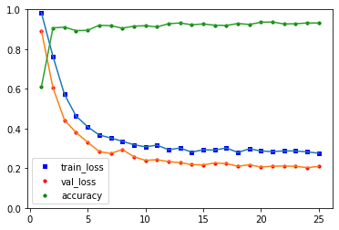

```python
train_loss, val_loss,accu = extract_values(data,epoch,learn,bs)
plot_matrix(epoch,train_loss,val_loss,accu)
```

#### Evaluate sensitivity, specificity, accuracy, precision, F1 score and plot confusion matrix, receiver operating characteristic

```python
# Extract probability and labels for validation datset
probs,targets = learn.get_preds(ds_type=DatasetType.Valid)
# Prediction
probs = np.argmax(probs, axis=1)
```

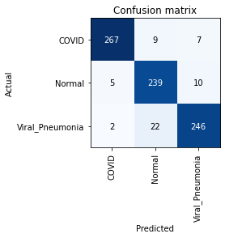

```python
# Plot confusion matrix
interp = ClassificationInterpretation.from_learner(learn)
cm_fig = interp.plot_confusion_matrix(return_fig=True)
ax = cm_fig.gca()
ax.set_ylim(interp.data.c - .5, - .5);
```

```python
# Plot classification report
target_names = ['Covid', 'Normal','Viral_Pneumonia']
print("Classification Report:")
print(classification_report(targets, probs, target_names=target_names))
```

```
Classification Report:
                 precision    recall  f1-score   support

          Covid       0.97      0.94      0.96       283
         Normal       0.89      0.94      0.91       254
Viral_Pneumonia       0.94      0.91      0.92       270

       accuracy                           0.93       807
      macro avg       0.93      0.93      0.93       807
   weighted avg       0.93      0.93      0.93       807
```

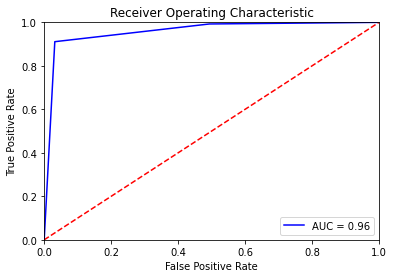

```python
# Receiver operating characteristic ROC is a probability curve created by plotting the TP rate against the FP rate at various threshold settings
fpr, tpr, _ = roc_curve(targets, probs, pos_label=2)
roc_auc = auc(fpr, tpr)

plt.title('Receiver Operating Characteristic')
plt.plot(fpr, tpr, 'b', label = 'AUC = %0.2f' % roc_auc)
plt.legend(loc = 'lower right')
plt.plot([0, 1], [0, 1],'r--')
plt.xlim([0, 1])
plt.ylim([0, 1])
plt.ylabel('True Positive Rate')
plt.xlabel('False Positive Rate')
plt.show()
```

#### Conclusion

The precision,recall,f1-score and AUC score indicated both the DarkCovidNet and GoogleNet model could effectively predict the category the x-ray image belongs to. We applied 5-fold cross validation and test validation to assess the fitness of the DarkCovidNet model. The loss value is comparable between CV and test validation, we didn't observe underfitting or overfitting problem.

This notebook demonstrated the potential predictive power of deep neural networks for diagnosis of COVID-19.